# Ford GoBike Data Set

## Olatunde Oyediran

## Introduction

> This data set includes information about over 183,000 individual rides made in a bike-sharing system covering the greater San Francisco Bay area. The dataset includes features such as the customer type, gender, birth year and ride duration amongst other variables.

> I wanted to know the factors that drove trips durations and i explored the other variables in this data set with the trip duration. I was curious about whether gender, member type, bike sharing, day of the week or time of the day affected how long trips lasted. The data set can be downloaded [here.](https://video.udacity-data.com/topher/2020/October/5f91cf38_201902-fordgobike-tripdata/201902-fordgobike-tripdata.csv)

### What is the structure of your dataset?

> The data set originally contained 16 variables or features and 183,412 observations. However, after some preliminary wrangling and feature engineering, i have 174,952 observations and 22 variables.

### What is/are the main feature(s) of interest in your dataset?

> I think ride duration(secs) is the stand out variable in this dataset. I am interested in the exploring how variables like gender, customer type, date, time, age and station affect how long a ride lasts.

### What features in the dataset do you think will help support your investigation into your feature(s) of interest?

> Duration(secs), gender, datetime, customer type, user type will all be explored to help answer some of my research questions.

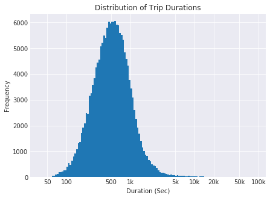

It appears the most rides occurred on Thursdays for the period. It will be interesting to see if this is as a result of some factors specific to Thursdays or simply a coincidence. However, it is clear that the least rides occur during the weekend.

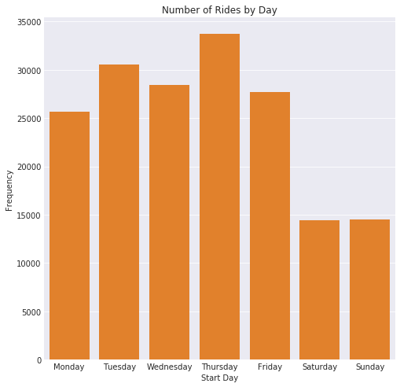

Peak period of rides are between 8 and 9am in the morning and 4 - 6pm in the evening - Rush Hours!

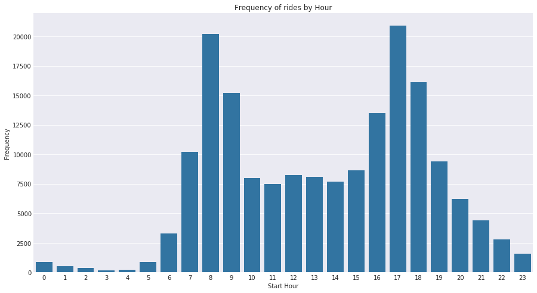

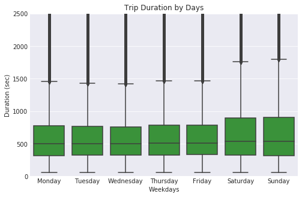

Females generally have higher trip durations than males and this does not change on weekends. Surprisingly, the other gender engage in longer trips than both males and females.

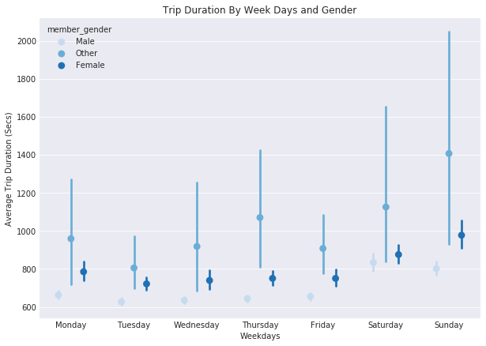